# Házi feladatok megoldása 5. Klaszterelemzés

Smahajcsik-Szabó Tamás, M9IJYM

### 1. Keress nemlineáris kapcsolatot a PIK 4 skálája és a PERMA Magányosság (Pmagány) és Teljesítmény (Ptelj) skálája között!

Az alábbi ábrán egy 2-4 fok közötti polinomiális trendvonalat illesztettem az adatokra. A legvilágosabb vonal lineáris trendvonal, míg a 2-4 fokok közti vonalak jelentős átfedéssel a sötét trendvonalak. További elemzések során, lokálisan súlyozott regressziós elemzést is futtattam (LOWESS), melz hasonlóképpen, elsősorban a Magányosság tétetelinél rajzolt ki nem lineáris kapcsolatokat.

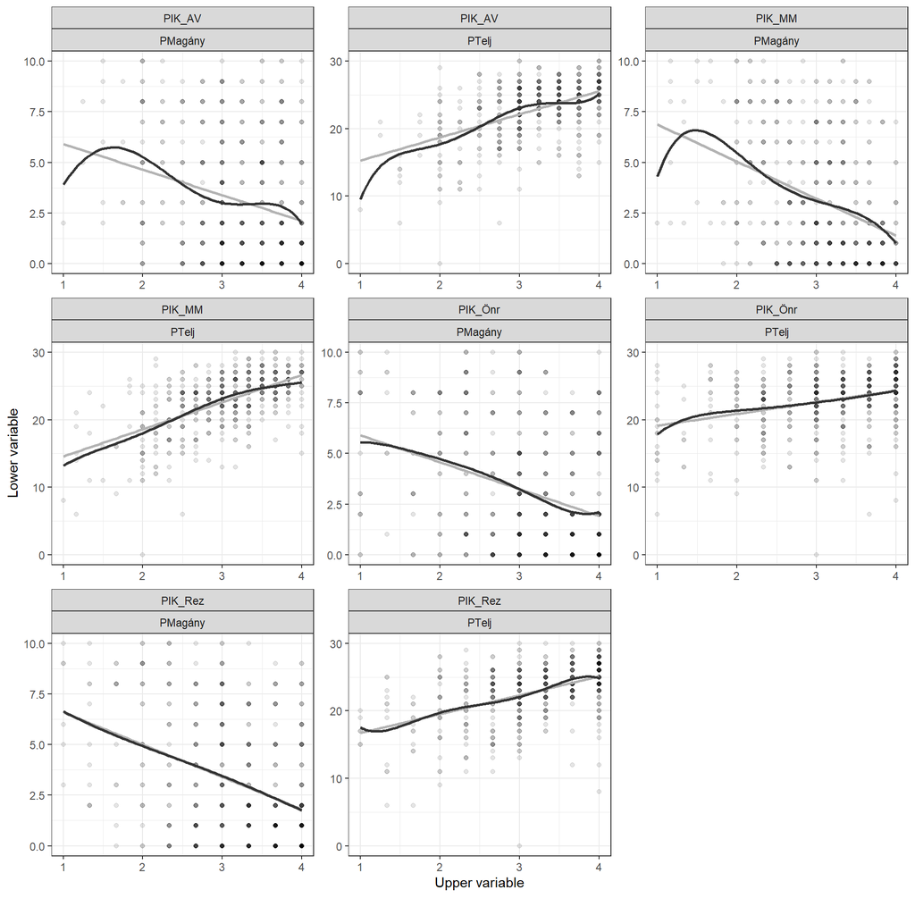

Mint a lentebbi táblázatból látható, a megmagyarázott variancia (adjusted R squared) értéke páronkénti polinomiális regressziók esetében maximum értékét nagyobb mint 1 értéknél éri el több változópár esetében is.A fok értékét 5-ben maximalizáltam, és a legtöbb esetben a harmadfokú polinomiális komponens eredményezi a legmagasabb magyarázott variancia arányt. Magasabb értékeknél (maximális fok 8) elltűnik a PIK-AV és a Magányosság esetén a lineáris kapcsolat, és egy nem lineáris trendvonal jobb magyarázó erőt képvisel.

[output not shown]

### 3. Számítsd ki a 4.4. ábrán látható KL2 és KL3 klaszter távolságát a 4.2. táblázat 1., 2., 3. és 5. távolságtípusára, ha a személytávolságra a SED távolságot használjuk!

| method | d |
| --- | --- |
| min | 13.00 |
| max | 52.00 |
| average | 31.50 |
| centroid | 27.36 |

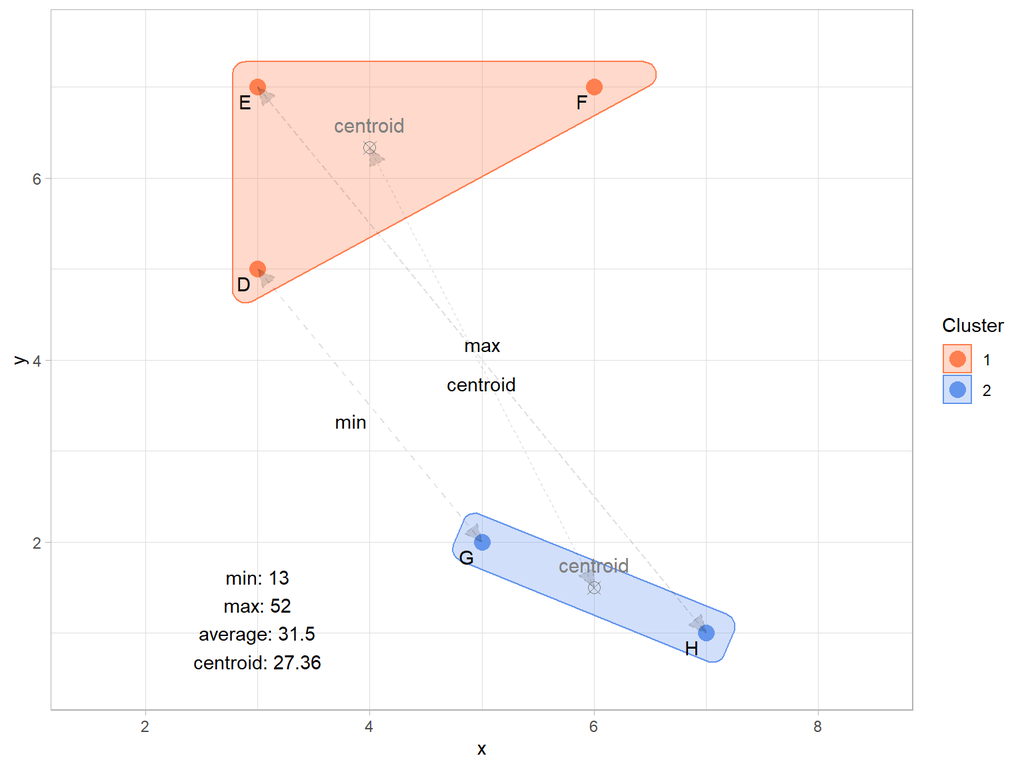

### 4. Számítsd ki a 4.4. ábrán látható KL2 és KL3 klaszter távolságát a 4.2. táblázat 1., 2., 3. és 5. távolságtípusára, ha a személytávolságra az ASED távolságot használjuk!

| method | d |
| --- | --- |
| min | 6.50 |
| max | 26.00 |
| average | 15.75 |
| centroid | 13.68 |

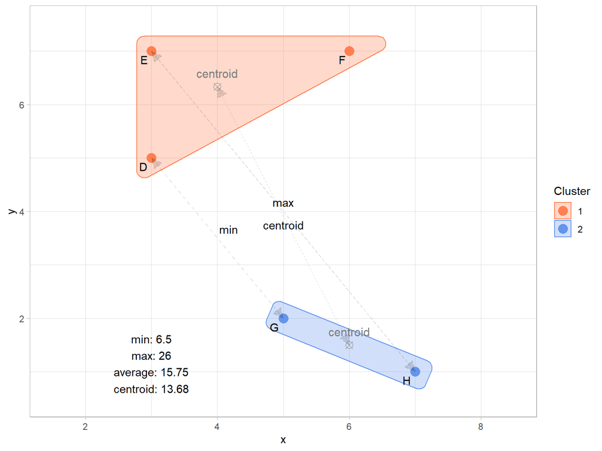

### 5. A ROPstat Relokáció modulja segítségével készíts 3, 4 és 5 klaszteres megoldást a Ptelj és Pmagány változóra standardizálással és hasonlítsd össze e megoldásokat a 4.4. táblázat adekvációs mutatói segítségével! Melyik klaszterstruktúra tűnik a legjobbnak?

| k | EESS. | Pontbisz | XBmod | Sil.eh. | HCĂ.tlag | CLdelta | GDI24 | HCmin.HCmax |
| --- | --- | --- | --- | --- | --- | --- | --- | --- |
| 3 | 64,96 | 0,51 | 0,792 | 0,769 | 0,705 | 1,041 | 1,004 | 0,43-1,67 |
| 4 | 74,59 | 0,497 | 0,845 | 0,782 | 0,512 | 1,047 | 1,572 | 0,33-1,04 |
| 5 | 78,94 | 0,459 | 0,743 | 0,759 | 0,426 | 1,012 | 0,783 | 0,30-1,04 |

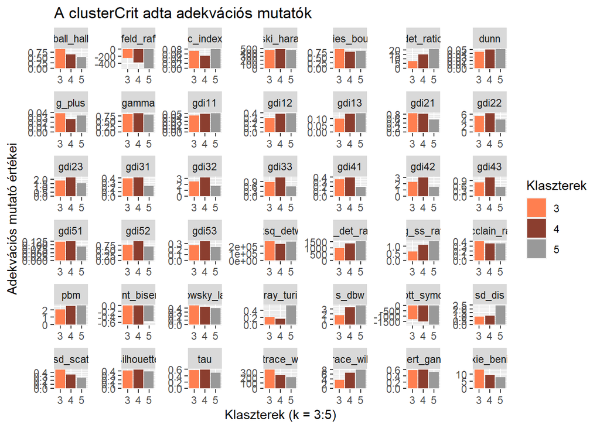